# fSuSiE: introduction to the key ideas with a toy methylation data set

William Denault and Peter Carbonetto

2025-02-10

In this vignette we illustrate some of the key ideas underlying fSuSiE by applying fSuSiE to analyze a toy methylation data set.

Load the packages used in this vignette.

```r
library(fsusieR)
library(reshape2)
library(ggplot2)
library(cowplot)
```

Set the seed so that the results can be reproduced.

```r
set.seed(1)
```

## Simulate data

We simulate a “toy” methylation data set in which the methylation levels of 100 individuals are measured at 32 CpGs.

Among the 12 candidate SNPs, 3 SNPs affect the methylation levels: 2 SNPs affect the methylation levels of the same cluster of 8 CpGs, and the other SNP affects the methylation levels of different cluster of 8 CpGs.

```r
n <- 100
m <- 32
p <- 12
```

Generate the SNP minor allele frequencies (MAFs):

```r
maf <- 0.05 + 0.45*runif(p)
```

Generate ids for SNPs and CpGs.

```r
snpids <- paste0("SNP-",1:p)
cpgids <- paste0("CpG-",1:m)
```

Simulate the genotypes:

```r
X <- (runif(n*p) < maf) +
     (runif(n*p) < maf)
X <- matrix(X,n,p,byrow = TRUE)
storage.mode(X) <- "double"
X[,4] <- X[,3] + 0.03*rnorm(n)
colnames(X) <- snpids
```

This is the matrix that determines how the SNP alleles change the methylation levels.

```r
F <- matrix(0,p,m)
F[1,9:16] <- 2.3
F[9,9:16] <- (-2.3)
F[3,25:32] <- 2
rownames(F) <- snpids
colnames(F) <- cpgids
```

Simulate the methylation levels at the CpGs:

```r
E <- matrix(3*rnorm(n*m),n,m)
Y <- X %*% F
Y <- Y + E
baseline <- min(Y)
Y <- Y - baseline
```

To make the example more realistic, the methylation levels are all simulated to be zero or higher.

To illustrate, this plot shows the effect of SNP 3 on the methylation levels. The points show what the data look like and the lines show the mean methylation levels for the three SNP genotypes:

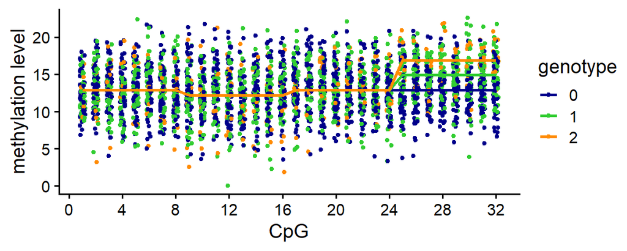

```r
pdat <- melt(Y)
x    <- X[,3]
pdat <- data.frame(cpg        = rep(1:m,each = n) +
                                runif(m*n,min = -0.2,max = 0.2),
                   meth_level = as.vector(Y),
                   geno       = factor(x))
pdat_lines <- data.frame(cpg = rep(1:m,times = 3),
                         geno = factor(rep(0:2,each = m)),
                         meth_level = rep(c(rep(0,8),rep(-0.75,8),rep(0,16)),
                                          times = 3))
pdat_lines$meth_level <- pdat_lines$meth_level - baseline
rows <- which(with(pdat_lines,geno == 1 & cpg > 24))
pdat_lines[rows,"meth_level"] <- pdat_lines[rows,"meth_level"] + 2
rows <- which(with(pdat_lines,geno == 2 & cpg > 24))
pdat_lines[rows,"meth_level"] <- pdat_lines[rows,"meth_level"] + 4
p1 <- ggplot(pdat,aes(x = cpg,y = meth_level,color = geno)) +
  geom_point(shape = 20,size = 1.25) +
  scale_x_continuous(breaks = c(0,seq(4,32,4))) +
  scale_color_manual(values = c("darkblue","limegreen","darkorange")) +
  geom_line(data = pdat_lines,size = 0.75) +
  labs(x = "CpG",y = "methylation level",color = "genotype") +
  theme_cowplot(font_size = 11)
# Warning: Using `size` aesthetic for lines was deprecated in ggplot2 3.4.0.
# ℹ Please use `linewidth` instead.
# This warning is displayed once every 8 hours.
# Call `lifecycle::last_lifecycle_warnings()` to see where this warning was generated.
print(p1)
```

## QTL mapping

In a typical methylation QTL mapping analysis, one would perform association tests for all the CpG-SNP pairs. Here we will simply use the standard linear regression function in R, `lm()`, to perform the QTL mapping.

```r
assoc <- matrix(0,m,p)
rownames(assoc) <- cpgids
colnames(assoc) <- snpids
for (i in 1:m) {
  for (j in 1:p) {
    dat <- data.frame(x = X[,j],y = Y[,i])
    fit <- lm(y ~ x,dat)
    assoc[i,j] <- summary(fit)$coefficients["x","Pr(>|t|)"]
  }
}
```

Having performed these tests for association, we can examine the associations in two different ways, by SNP and by CpG site. Let’s start with the SNP-centered view:

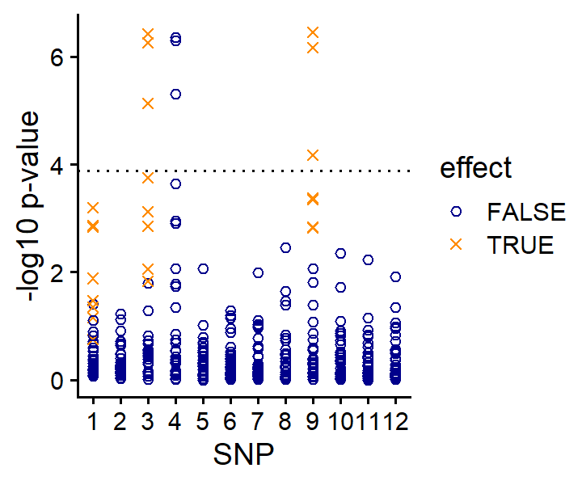

```r
pdat <- data.frame(cpg    = rep(1:m,times = p),
                   snp    = rep(1:p,each = m),
                   effect = as.vector(t(F != 0)),
                   pval   = as.vector(assoc))
pdat <- transform(pdat,pval = -log10(pval))
threshold <- -log10(0.05/(m*p))
p2 <- ggplot(pdat,aes(x = snp,y = pval,shape = effect,color = effect)) +
  geom_point(size = 1.5) +
  geom_hline(yintercept = threshold,color = "black",linetype = "dotted") +
  scale_x_continuous(breaks = 1:p) +
  scale_shape_manual(values = c(1,4)) +
  scale_color_manual(values = c("darkblue","darkorange")) +
  labs(x = "SNP",y = "-log10 p-value") +
  theme_cowplot(font_size = 11)
print(p2)
```

Based on these simple association tests, we would identify two out of the three causal SNPs. (And perhaps we would identify all three causal SNPs if we were a bit more careful about multiple testing correction—here we just used the basic Bonferroni correction, which tells us that only the CpG-SNPs pairs with p-values less than 0.0001 are significant.)

*But more importantly*, this view alone doesn’t tell us which CPGs are affected by the SNPs.

This is the CpG-centered view:

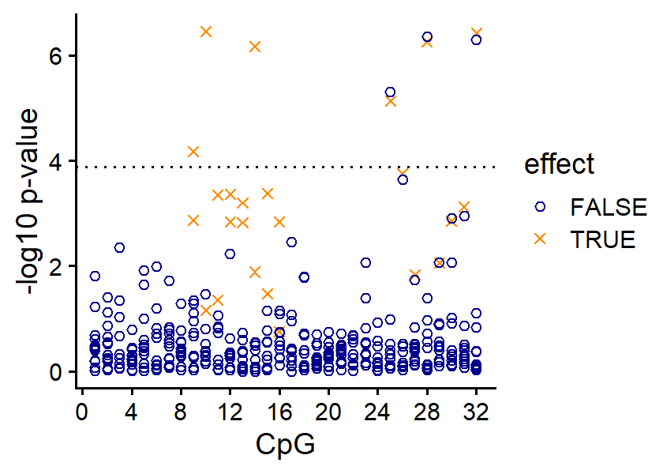

```r
p3 <- ggplot(pdat,aes(x = cpg,y = pval,shape = effect,color = effect)) +
  geom_point(size = 1.5) +
  geom_hline(yintercept = threshold,linetype = "dotted") +
  scale_x_continuous(breaks = c(0,seq(4,32,4))) +
  scale_shape_manual(values = c(1,4)) +
  scale_color_manual(values = c("darkblue","darkorange")) +
  labs(x = "CpG",y = "-log10 p-value") +
  theme_cowplot(font_size = 11)
print(p3)
```

From the association test p-values alone it is quite clear that the affected CpG sites “cluster” in two continuous regions, but it is less clear exactly which CpG sites in these clusters are affected.

*But more importantly*, this view alone doesn’t tell us which SNPs are affecting the changes in the methylation levels at these CpGs.

## Fine-mapping with fSuSiE

Let’s now contrast the above QTL mapping analysis with an analysis of the methylation data using fSuSiE. First we fit the fSuSiE model to the data. *Notice that we only a fit a single model to all the data*:

```r
fit <- susiF(Y,X,L = 3,filter_cs = FALSE,prior = "mixture_normal",
             post_processing = "HMM")
```

(In this example it is assumed that we know that there are three causal SNPs, but more generally this number can be estimated.)

fSuSiE correctly produced 3 credible sets (95% CSs) each containing one of the causal SNPs:

```r
fit$cs
# [[1]]
# SNP-9
#     9
#
# [[2]]
# SNP-3 SNP-4
#     3     4
#
# [[3]]
# SNP-1
#     1
```

This result can be visualized using a “PIP plot” (PIP = posterior inclusion probability):

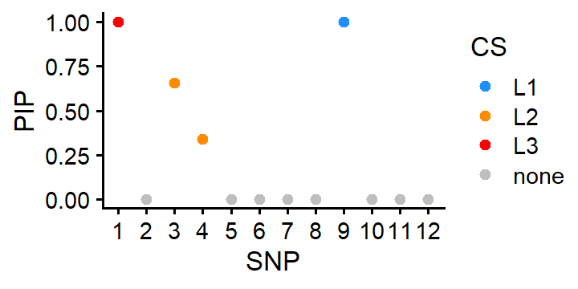

```r
cs_colors <- c("dodgerblue","darkorange","red")
pdat <- data.frame(SNP = 1:p,
                   PIP = fit$pip,
                   CS  = rep("none",p))
pdat$CS[fit$cs[[1]]] <- "L1"
pdat$CS[fit$cs[[2]]] <- "L2"
pdat$CS[fit$cs[[3]]] <- "L3"
pdat <- transform(pdat,CS = factor(CS))
p4 <- ggplot(pdat,aes(x = SNP,y = PIP,fill = CS)) +
  geom_point(shape = 21,size = 2,color = "white") +
  scale_x_continuous(breaks = 1:p) +
  scale_fill_manual(values = c(cs_colors,"gray")) +
  theme_cowplot(font_size = 10)
print(p4)
```

fSuSiE also gives a more coherent view of changes to the CpG sites and how they are affected by the individual causal SNPs (or, more precisely, by the individual CSs). Here we use the *lfsr* (*local false sign rate*) estimates produced by the HMM (using the `post_processing = "HMM"` option):

```r
i <- sapply(fit$cs,function (x) intersect(x,c(1,3,9)))
pdat <- data.frame(CS   = rep(c("L1","L2","L3"),each = m),
                   CpG  = rep(1:m,times = 3),
                   lfsr = unlist(fit$lfsr_func),
                   affected = as.vector(t(F[i,]) != 0),
                   stringsAsFactors = FALSE)
pdat <- transform(pdat,
                  CS   = factor(CS,c("L3","L2","L1")),
                  lfsr = -log10(lfsr))
ggplot(pdat,aes(x = CpG,y = CS,size = lfsr,color = affected)) +
  geom_point(shape = 1) +
  scale_x_continuous(breaks = c(0,seq(4,32,4))) +
  scale_color_manual(values = c("darkblue","darkorange")) +
  scale_size(range = c(0.5,10),breaks = c(1.3,5,10)) +
  labs(size = "-log10(lfsr)") +
  theme_cowplot(font_size = 10)
```

[output not shown]

Indeed, the significance tests (local false sign rate) break down the support for affected CpGs *separately for each CS* (i.e., for each causal SNP), and therefore it is quite evident from the fSuSiE results that two of the causal SNPs affect the same CpG cluster, and the other causal SNP affects a different CpG cluster.

## TI wavelet estimates

An alternative to the HMM post-processing step is to use the TI (“translation invariant”) wavelets to estimate the effects and their credible bands:

```r
fit_TI <- susiF(Y,X,L = 3,filter_cs = FALSE,prior = "mixture_normal",
                post_processing = "TI")
```

Note that the post-processing step doesn’t change the CSs (nor the PIPs), only the estimated effects of the SNPs on the CpGs.

```r
range(fit$pip - fit_TI$pip)
fit_TI$cs
# [1] 0 0
# [[1]]
# SNP-9
#     9
#
# [[2]]
# SNP-3 SNP-4
#     3     4
#
# [[3]]
# SNP-1
#     1
```

These are the TI wavelet estimates of the effects on the CpG sites (and corresponding credible bands):

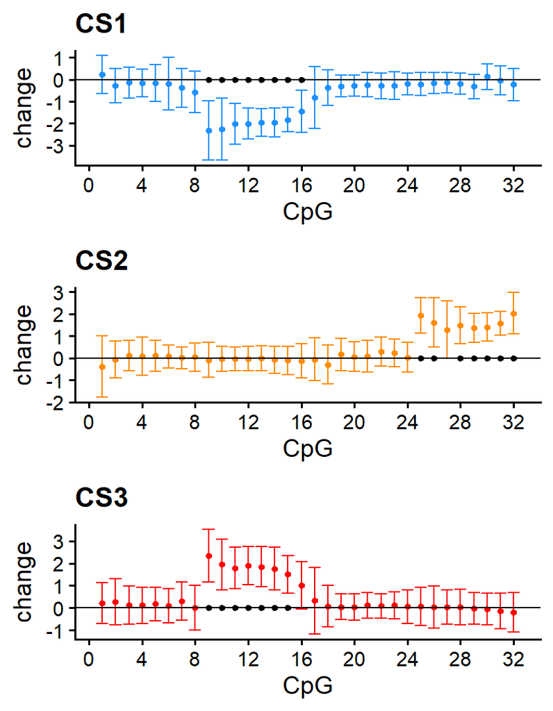

```r
effect_plot <- function (i) {
  pdat <- data.frame(cpg      = 1:m,
                     estimate = fit_TI$fitted_func[[i]],
                     lower    = fit_TI$cred_band[[i]]["low",],
                     upper    = fit_TI$cred_band[[i]]["up",])
  rows <- with(pdat,which(lower > 0 | upper < 0))
  pdat2 <- data.frame(cpg = rows,estimate = 0)
  return(ggplot(pdat,aes(x = cpg,y = estimate,ymin = lower,ymax = upper)) +
         geom_point(color = cs_colors[i],size = 1) +
         geom_errorbar(color = cs_colors[i],linewidth = 0.4) +
         geom_hline(yintercept = 0,color = "black",linewidth = 0.4) +
         geom_point(data = pdat2,mapping = aes(x = cpg,y = estimate),
                    shape = 20,color = "black",size = 1.5,
                    inherit.aes = FALSE) +
         scale_x_continuous(breaks = c(0,seq(4,32,4))) +
         labs(x = "CpG",y = "change",title = paste0("CS",i)) +
         theme_cowplot(font_size = 11))
}
plot_grid(effect_plot(1),
          effect_plot(2),
          effect_plot(3),
          nrow = 3,ncol = 1)
```

Notice that the effect estimates with (95%) credible bands outside zero predict very accurately the affected CpG sites.

## Session info

This is the version of R and the packages that were used to generate these results.

```r
sessionInfo()
# R version 4.3.3 (2024-02-29 ucrt)
# Platform: x86_64-w64-mingw32/x64 (64-bit)
# Running under: Windows 11 x64 (build 26120)
#
# Matrix products: default
#
#
# locale:
# [1] LC_COLLATE=C
# [2] LC_CTYPE=English_United States.utf8
# [3] LC_MONETARY=English_United States.utf8
# [4] LC_NUMERIC=C
# [5] LC_TIME=English_United States.utf8
#
# time zone: Etc/GMT-1
# tzcode source: internal
#
# attached base packages:
# [1] stats     graphics  grDevices utils     datasets  methods   base
#
# other attached packages:
# [1] reshape2_1.4.4 cowplot_1.1.3  ggplot2_3.5.1  susieR_0.12.35 fsusieR_0.2.87
#
# loaded via a namespace (and not attached):
#  [1] tidyselect_1.2.1     farver_2.1.2         dplyr_1.1.4
#  [4] bitops_1.0-9         fastmap_1.2.0        reshape_0.8.9
#  [7] promises_1.3.2       digest_0.6.37        mime_0.12
# [10] lifecycle_1.0.4      ellipsis_0.3.2       invgamma_1.1
# [13] magrittr_2.0.3       compiler_4.3.3       rlang_1.1.5
# [16] sass_0.4.9           tools_4.3.3          yaml_2.3.10
# [19] data.table_1.16.4    knitr_1.49           labeling_0.4.3
# [22] htmlwidgets_1.6.4    pkgbuild_1.4.6       plyr_1.8.9
# [25] xml2_1.3.6           pkgload_1.4.0        miniUI_0.1.1.1
# [28] withr_3.0.2          purrr_1.0.2          desc_1.4.3
# [31] grid_4.3.3           roxygen2_7.3.2       urlchecker_1.0.1
# [34] profvis_0.4.0        caTools_1.18.3       xtable_1.8-4
# [37] colorspace_2.1-1     scales_1.3.0         MASS_7.3-60.0.1
# [40] cli_3.6.3            rmarkdown_2.29       crayon_1.5.3
# [43] generics_0.1.3       remotes_2.5.0        RcppParallel_5.1.10
# [46] rstudioapi_0.17.1    LaplacesDemon_16.1.6 sessioninfo_1.2.2
# [49] cachem_1.1.0         stringr_1.5.1        parallel_4.3.3
# [52] matrixStats_1.5.0    vctrs_0.6.5          devtools_2.4.5
# [55] Matrix_1.6-5         jsonlite_1.8.9       mixsqp_0.3-54
# [58] irlba_2.3.5.1        wavethresh_4.7.3     jquerylib_0.1.4
# [61] glue_1.8.0           stringi_1.8.4        gtable_0.3.6
# [64] later_1.4.1          RcppZiggurat_0.1.6   munsell_0.5.1
# [67] tibble_3.2.1         pillar_1.10.1        htmltools_0.5.8.1
# [70] truncnorm_1.0-9      R6_2.5.1             smashr_1.2-9
# [73] rprojroot_2.0.4      evaluate_1.0.3       shiny_1.10.0
# [76] lattice_0.22-5       Rfast_2.1.4          memoise_2.0.1
# [79] SQUAREM_2021.1       ashr_2.2-63          httpuv_1.6.15
# [82] bslib_0.9.0          Rcpp_1.0.14          xfun_0.50
# [85] fs_1.6.5             usethis_3.1.0        pkgconfig_2.0.3
```